# STT1810 — Example 6.1 Geyser Eruptions

Last updated Thursday, April 27, 2023 @ 01:06 AM

## Before We Begin…

These slides are intended to accompany Section 6.1 Comparing Two Groups: Quantitative Response in [*Introduction to Statistical Investigations, 2nd Edition*](http://www.isi-stats.com/isi/index2nd.html).

*This content does not replace reading the textbook section.* It is for class presentation and reference.

See Also:

- [Section 2.1 Exploring Data](https://stat-jet-asu.github.io/STT1810BasicStatistics/Slides/CH2_1.html)
- [Example 2.1 Oh, Say Can You Sing?](https://stat-jet-asu.github.io/STT1810BasicStatistics/Slides/Example2_1.html)
- [Section 6.1 Compare Two Groups: Quantitative Response](https://stat-jet-asu.github.io/STT1810BasicStatistics/Slides/CH6_1.html)
- [Section 6.2 Compare Two Means: Simulation-Based](https://stat-jet-asu.github.io/STT1810BasicStatistics/Slides/CH6_2.html)
- Example 6.2 Dung Beetles (TBA)

Old Faithful (Yellowstone National Park) erupts around 20 times a day. [According to the National Park Service](https://www.yellowstonepark.com/things-to-do/geysers-hot-springs/about-old-faithful/), “… eruptions are predicted with a 90 percent confidence rate, within a 10 minute variation,” based on duration/height of the previous eruption.

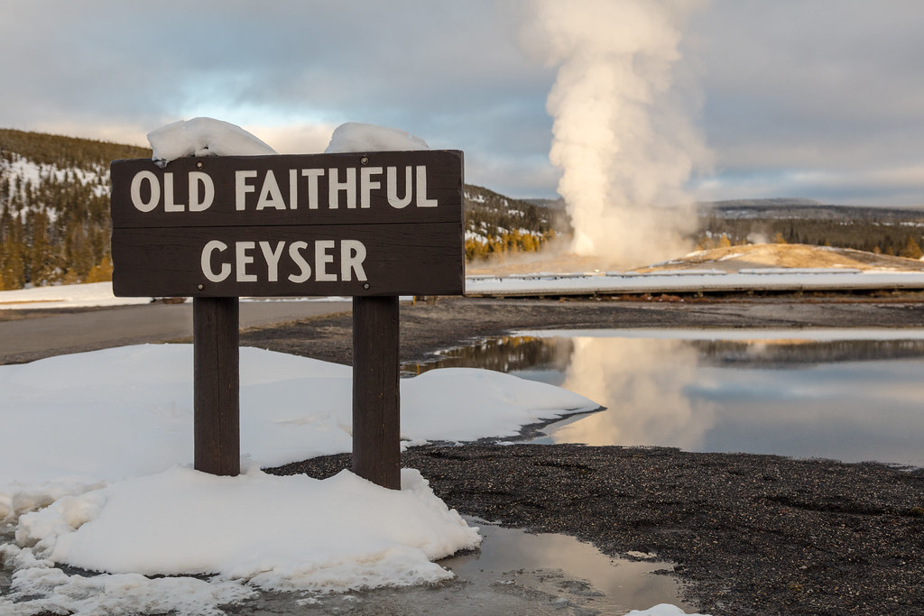

## STEP 1: Ask a Research Question

The National Park Service’s website presents a question that has been asked many times: “I heard Old Faithful isn’t as faithful as it used to be. Is it slowing down?”

Their answer is the information presented on the previous slide about being able to predict eruptions, and also that the number *may* have decreased a little over time. Perhaps we can better explore this question by examining some data.

**research question:** Has there been a change in Old Faithful’s eruption pattern between 1978 and 2003? Is it slowing down?

Note: We will be exploring *time between eruptions*. However, if the time *between* eruptions changes, then so does the number or pattern of eruptions per day.

## STEP 2: Design a Study / Collect Data

**type of study:** observational study (*why*?)

**observational units:** individual geyser eruptions

**explanatory variable:** year (binary categorical, 1978 or 2003)

**response variable:** time until the next eruption (quantitative)

**measurement units:** the quantitative variable “time until the next eruption” is measured in minutes

**data:** eruptions that occurred from August 1 to August 8, 1978 (6:00am to midnight), also from the same time interval in 2003

*Choosing the same time period for both years helps to reduce some of the possible confounding variables.*

## STEP 3: Explore the Data

We can explore these data in the [ISI Descriptive Statistics applet](http://www.isi-stats.com/isi2nd/ISIapplets2021.html).

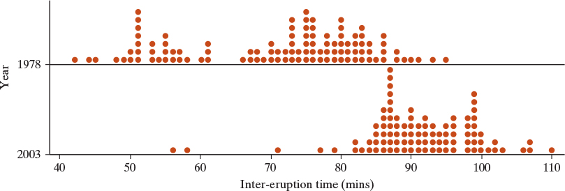

- What is the shape of each distribution?
- What is the center of each distribution?
- What is the spread (variability) of each distribution?
- Does either distribution have any unusual points/outliers?
- How do the two distributions compare to one another?

## Comparing with Statistics

| Year | Mean | SD | Minimum | Lower Quartile | Median | Upper Quartile | Maximum | Interquartile Range (IQR) |
| --- | --- | --- | --- | --- | --- | --- | --- | --- |
| 2003 | 91.2 | 8.5 | 56 | 87 | 91 | 98 | 110 | 11 |
| 1978 | 71.1 | 12.9 | 42 | 58 | 75 | 81 | 95 | 23 |
| diff | 20.1 | -4.4 | 14 | 29 | 16 | 17 | 15 | -12 |

- Measures of center increased (mean, median)
- Measures of variability decreased (SD, IQR)
- Five-number summary increased (min, Q<sub>1</sub>, med, Q<sub>3</sub>, max)

## Comparing with Boxplots

The box displays the middle 50% of the distribution; its width is the IQR. The whiskers extend to the smallest and largest values in the dataset *that are not outliers*.

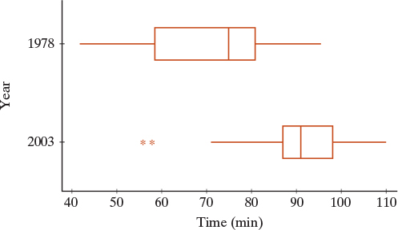

There appear to be two lower outliers in 2003 (the * on the plot). What are the cutoffs for outliers in each of the two years?

A data point may be an outlier *relative to the group it belongs to*.

**For 1978:**

\(\text{lower quartile} - 1.5 * IQR = 58 - (1.5 * 23) = 23.5\)

\(\text{upper quartile} + 1.5 * IQR = 81 + (1.5 * 23) = 115.5\)

*None of the data points in 1978 fall outside these two boundaries.*

**For 2003:**

\(\text{lower quartile} - 1.5 * IQR = 87 - (1.5 * 11) = 70.5\)

\(\text{upper quartile} + 1.5 * IQR = 98 + (1.5 * 11) = 114.5\)

*As we can see on our plots, there are two data points < 70.5.*

## STEP 4: Draw Inferences

In Section 6.2, you will learn how to use simulation to compare two group means to assess a statistical significance.

As we did with proportions, we will be looking at the difference between the two groups. We will use \(\mu_1 - \mu_2\) to represent the difference in the population and \(\bar{x}_1 - \bar{x}_2\) for the sample.

Here we have \(\bar{x}_{2003} - \bar{x}_{1978}\) = 91.2 - 71.1 = 20.1 minutes. Is this difference just random chance, or has Old Faithful’s underlying process really changed?

The same method could also be used to compare two *medians*, if we think the median is a better measure of center.

Researchers have to be careful about the scope of conclusions they draw from this kind of observational study.

## Think About It…

Based on the distributions of times between eruptions, in which year would you have preferred to be a tourist waiting for the next eruption of Old Faithful? Can you think of one way in which 1978 would have been preferable and a different way in which 2003 would have been preferable?

- If you are a tourist who cares most about having a shorter wait for the next eruption, you would have preferred 1978. This is because the *average* wait time was about 20 minutes less in 1978 than in 2003.
- If your primary concern is being able to predict accurately when the next eruption would occur, then you would have preferred 2003. This is because the *variability* in wait times was much smaller than in 1978.

## For the Curious…

\[H_0: \mu_{2003} = \mu_{1978} \text{ vs. } H_a: \mu_{2003} > \mu_{1978}\]

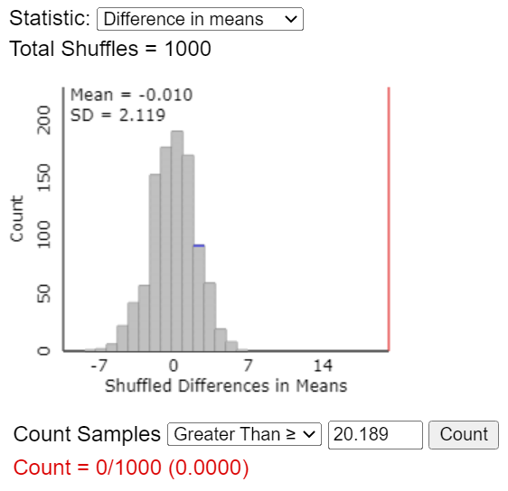

Based on the data, what should we conclude about Old Faithful?